# Is there an equitable distribution of vaccines for everyone?

Lynette Gao, JIAYI HONG,Jacky Chen, Xinyue Li, Wai Tsun Chan

5/1/2021

*Overall Note: please open this html file in Browser*

### 1. Introduction

#### Motivation and literature review

By January 28th of 2021, the World Health Organization (WHO) has recorded over one billion confirmed cases of COVID-19 and over two million deaths, which is causing a catastrophe for human society. With the impacts of COVID-19 affecting the economy and public health on a global scale, the director of the National Institute of Allergy and Infectious Diseases (NIAID) described this pandemic as “the worst global pandemic in more than 100 years of history.”

To resolve the coronavirus pandemic, governments and people around the world placed high hopes on the vaccines, but vacation campaigns face difficulties on the global distribution due to limited availability, public mistrust, and dosage and storage requirements (Felter, 2021). We are interested in the equality of vaccine distribution across different countries via three models, including economy, geography, and education. In terms of economy, similar to the human papillomavirus vaccine, COVID-19 vaccines can face shortages due to conflict and insufficient production capacity (Felter, 2021), the countries with better economy could have higher priority of access to vaccines. Geography is another possible reason that affects the equality of vaccine distribution. The COVID-19 vaccines, such as the Pfizer-BioNTech vaccine, must be stored in ultra-cold freezers during transport, known as the cold-chain challenges (Felter, 2021). Therefore, we expect the countries with higher population density are more likely to be cold-chains ready, insisting a higher chance of accessing the vaccines. In public understanding, professor William Schaffner reacted to the survey result that only 37 percent of Americans are comfortable being the first group of people to get vaccinated. He described the result as “a terrific amount of education, coupled with reassurance (Felter, 2021).” This perspective led us to consider the effects of education on the number of people who get vaccinated.

#### Thesis

In this report, with the use of visualization and statistical analysis, we aim to answer the following question “Education, economy, demography - what are the factors that induce inequalities in access to COVID vaccine ?” In section 3, we will present several overview visualizations to help the readers to have a general understanding of the vaccination progress, such as what country or region vaccinated more people. After a general introduction, we will dive deep into the question of whether inequity exists in vaccine distribution in section 4.

### 3. Overview

#### 3.1 World map

For the overview part, a variable indicating the proportion of people vaccinated for at least one shot “people vaccinated per hundred” was used to represent the overall vaccination rate from a worldwide perspective. The first plot we generated was a global interaction map. Colors ranging from light yellow to dark blue represent low to high vaccination rates for each country. Moreover, the color grey represents data missing for this country. Also, we made this plot interactively if people need to know the exact vaccination rate for a country. Data for each country would pop up by moving a mouse around the map.

(Figure 1) Vaccination progress across the world

[interactive chart not shown]

Note:

1. the grey color stands for NA
2. the interaction needs some time to load before functioning normally, please wait for 5 seconds

#### 3.2 Boxplot

(Figure 2) Vaccination progress across different regions

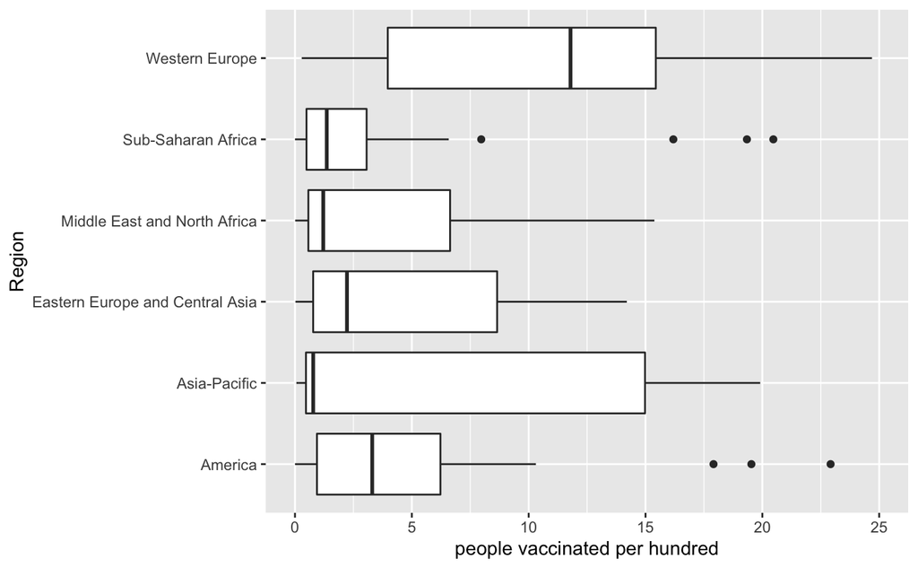

Please make sure to download the images in the same folder

Therefore, it is reasonable for us to question whether the Covid-19 vaccinations are distributed equally worldwide. So as to explain these differences across countries and regions. After doing literature review (Section 1.1), we conducted analysis on the following factors: economy, demography, and education conditions.

### 4. Discussion

#### 4.1 Economy

In terms of economy, we want to find out if the countries with higher GDP growth rate have higher priority of access to vaccines. GDP growth rate measures the comparative health of an economy over time, therefore this will be a fine measure for measuring the economy for each individual country’s economic performance, regardless of economic scale. We answer this question by creating a scatterplot of the 2019-2020 Gross Domestic Product (GDP) growth rate in percentage vs the number of vaccinated people per hundred, and the size of each scatter highlights the GDP of each country in terms of US dollar (in billion).

(Figure 3) Scatterplot for GDP growth rate and vaccination

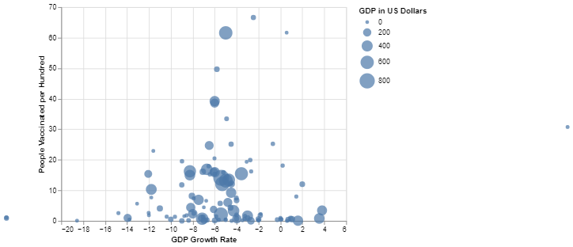

From the graph, there is no obvious trend that shows a positive correlation between GDP growth rate and number of vaccinated people per hundred, thus, we further perform a Pearson correlation test.

(Figure 4) Regression plot for GDP growth rate and vaccination

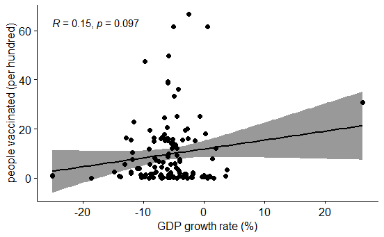

By the Pearson correlation test at 5% alpha level, we set the null hypothesis to be the true correlation is equal to zero; and the alternative hypothesis of this test is that the true correlation is not equal to zero. As a result, the Pearson’s product-moment correlation test has the correlation coefficient at 0.1491701 with a p-value of 0.09685; thus, we confirmed that two variables do not correlate to each other because of the p-value does not lower than the alpha 0.05.

#### 4.2 Demography

We are also interested in whether or not the countries’ demographic information could impact the distribution of the vaccine because, intuitively, a low population or population density could mean that distribution needs more traveling time and efforts to achieve the same number of people. Also, demographic information affects the number of clinics and hospitals available. We believe that this is a meaningful topic to explore.

(Figure 5-9) Relationship between vaccination rate and population density

[figure not shown]

[figure not shown]

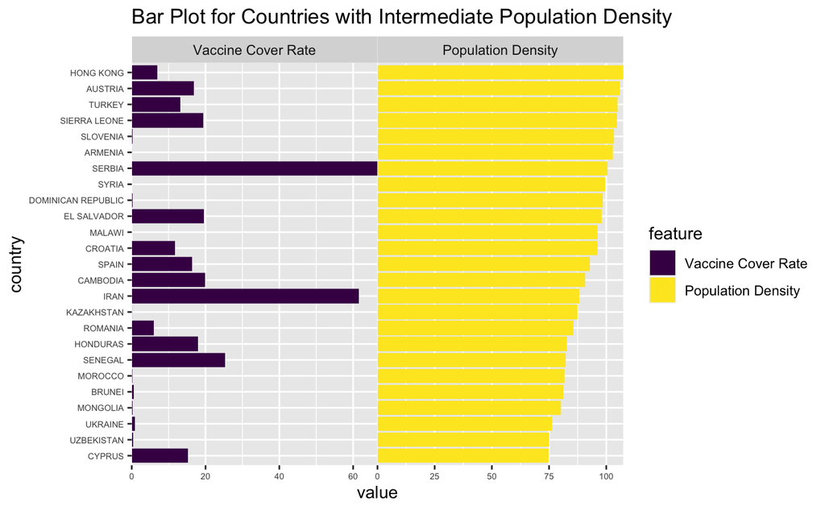

[figure not shown]

[figure not shown]

(Figure 10) Relationship between vaccination rate and population density for countries with Top20 vaccination rate

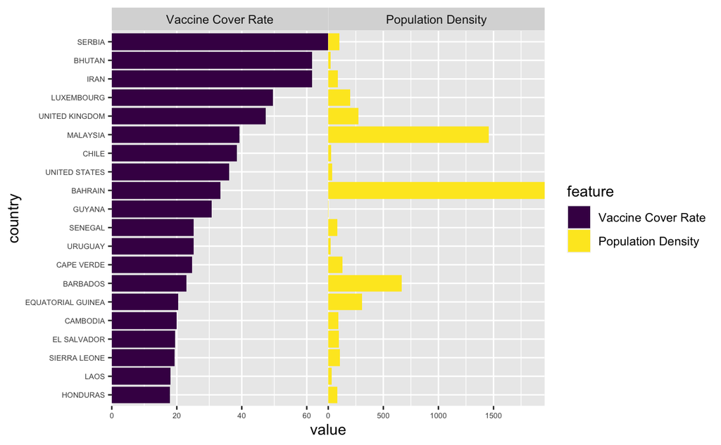

The top20 vaccine cover rate plot helps further the investigation. By filtering the countries with the top vaccine cover rate per hundred of people, we can zoom in to see individual cases and try to find some common characteristics about them. However, the plot shows population density that is extremely high and low, and of average values. We cannot find strong evidence that these 2 variables are related.

In summary, we cannot conclude that there is strong relationship between vaccination rate and population density. There are many factors related to population density that can impact the vaccination coverage intutively, and we suspect that it is possible the effects can be offset with one another. For example, while a low population density requires more efforts to transport the vaccines, at the same time it could need less space to distribution them.

#### 4.3 Education

Next we look into the factor of education. [Previous study](https://bmcpublichealth.biomedcentral.com/articles/10.1186/s12889-018-5810-1#citeas) by Mora and Trapero-Bertran has shown that parental education has an influence on their children’s public health-care use in terms of visits for vaccinations, since they tend to use public health resources more frequently in childhood immunization schedules. Therfore, we are interested to see whether education factor will play also a role in COVID vaccinations.

(Figure 11) Vaccination progress by education level

[interactive chart not shown]

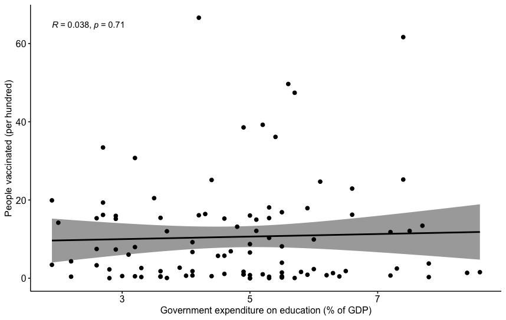

One possible reason to explain the low correlation between education and COVID vaccinations is that unlike other childhood immunizations, COVID vaccine is an essential factor to help achieve community immunity against virus. In order to get through this pandemic, every country is trying their best to release doses for public access. Therefore, there does not exist barrier for people at different educated level to receive doses.

#### 5. Conclusion

With the overview of vaccination cover rate in the introduction, we can see that some countries have a relatively more successful vaccination distribution. That is what inspire us to investigate further into whether or not there exists a possible inequality. However, after we concentrated on 3 topics, education level, population density, and economic growth, we fail to discover a strong indication of that inequality exist within the 3 area, specifically, around the parameters that we have chosen to study. Although we observe that a more developed country, either on education level or economic development, can have a higher vaccination rate, the relation is not always versing. We discussed the possible explanation for the weak relationships. We hope that with more up-to-date information, we can study further into the issue.